# 8月11日

```python
import pandas as pd
import numpy as np
import matplotlib.pyplot as plt
```

```python
data=pd.read_csv("./boss岗位.csv")
```

```python
#修改列名
a=['岗位']
a.extend(list(data.columns[1:]))
data.columns=a
```

```python
data.sample(5)
```

|  | 岗位 | 地区 | 公司名 | 公司领域 | 薪资 | 经验 | 规模 | 福利 | 详情页 |
| --- | --- | --- | --- | --- | --- | --- | --- | --- | --- |
| 2840 | 大数据开发 | 威海·环翠区·草庙子 | 中软国际 | 计算机软件 | 10-15K | 经验不限本科 | 10000人以上 | 餐补，零食下午茶，带薪年假，免费班车，节日福利，年终奖，定期体检，员工旅游，加班补助，五险一金 | https://www.zhipin.com/job_detail/4c25812b39e3... |
| 752 | 大数据开发工程师 | 成都·锦江区·天府广场 | 宇信科技 | 计算机软件 | 11-20K | 5-10年本科 | 1000-9999人 | 带薪年假，节日福利，年终奖，补充医疗保险，餐补，五险一金，通讯补贴，免费班车，司龄福利假期，... | https://www.zhipin.com/job_detail/e285b19c825a... |
| 1176 | 数据挖掘 | 北京·海淀区·西北旺 | 百度 | 互联网 | 20-30K | 1-3年本科 | 10000人以上 | 节日福利，通讯补贴，员工旅游，免费班车，加班补助，餐补，交通补助，住房补贴，年终奖，带薪年假... | https://www.zhipin.com/job_detail/0649819cc500... |
| 2834 | 大数据开发 | 南京·雨花台区·铁心桥 | 中软国际 | 计算机软件 | 13-26K | 经验不限本科 | 10000人以上 | 免费班车，五险一金，餐补，零食下午茶，年终奖，员工旅游，加班补助，带薪年假，定期体检，节日福利 | https://www.zhipin.com/job_detail/67288b9757b2... |
| 2563 | 视频会议运维工程师 | 北京·西城区·新街口 | 中国电信集成 | 通信/网络设备 | 12-14K | 5-10年大专 | 10000人以上 | 五险一金，5G内部套餐，加班补助，节日福利，年终奖，专业培训资源，交通补助，餐补，培训资源丰... | https://www.zhipin.com/job_detail/1384968dc832... |

```python
data.info()
```

```
<class 'pandas.core.frame.DataFrame'>
RangeIndex: 2913 entries, 0 to 2912
Data columns (total 9 columns):
 #   Column  Non-Null Count  Dtype
---  ------  --------------  -----
 0   岗位      2913 non-null   object
 1   地区      2913 non-null   object
 2   公司名     2913 non-null   object
 3   公司领域    2913 non-null   object
 4   薪资      2913 non-null   object
 5   经验      2913 non-null   object
 6   规模      2913 non-null   object
 7   福利      2531 non-null   object
 8   详情页     2913 non-null   object
dtypes: object(9)
memory usage: 204.9+ KB
```

# 数据预处理

### 处理地区数据

```python
# 提取地区
data['地区'].unique()
```

```
array(['北京·海淀区·公主坟', '上海·浦东新区·张江', '北京·大兴区·亦庄', ..., '东莞·长安镇·长安新区',
       '东莞·寮步镇·凫山', '海口·美兰区·明珠广场'], dtype=object)
```

```python
#提取城市名
data['地区']=data['地区'].str.partition('·')[0]
```

```python
data['地区'].unique()
```

```
array(['北京', '上海', '杭州', '佛山', '深圳', '厦门', '广州', '武汉', '湖州', '嘉兴', '郑州',
       '廊坊', '哈尔滨', '重庆', '西宁', '宁波', '长沙', '烟台', '南京', '泉州', '成都', '西安',
       '福州', '沈阳', '温州', '南昌', '天津', '南通', '苏州', '东莞', '石家庄', '海口', '台州',
       '商丘', '临汾', '绍兴', '新乡', '长春', '漯河', '金华', '济南', '呼伦贝尔', '毕节', '昆明',
       '贵阳', '唐山', '安阳', '合肥', '渭南', '焦作', '南宁', '珠海', '洛阳', '绵阳', '莆田',
       '泰安', '临沂', '太原', '聊城', '青岛', '无锡', '十堰', '清远', '大连', '潍坊', '许昌',
       '徐州', '长治', '常州', '连云港', '阜阳', '梅州', '威海', '丽水', '巴音郭楞蒙古自治州', '德阳',
       '营口', '中山', '保定', '沧州', '宝鸡', '上饶', '盘锦', '河源', '滨州', '日照', '桂林',
       '德州', '大同', '岳阳', '惠州', '吕梁', '开封', '九江', '赤峰', '昌吉回族自治州', '运城',
       '张家口', '呼和浩特', '乌鲁木齐', '三亚', '兰州', '白城', '晋城', '宿迁', '西双版纳傣族自治州',
       '漳州', '龙岩', '郴州', '赣州', '吉安', '柳州', '马鞍山', '晋中', '遵义', '盐城', '银川',
       '孝感', '乌兰察布', '濮阳', '镇江', '眉山', '襄阳', '淄博', '扬州', '承德', '南平', '泸州',
       '邢台', '吴忠', '济宁', '亳州', '宿州', '宁德', '南阳', '阳泉', '平顶山', '荆门', '衡阳',
       '株洲', '衡水', '江门', '鹤壁', '阳江', '秦皇岛', '淮南', '邯郸', '湘西土家族苗族自治州',
       '汕头', '包头', '黄冈', '东营', '泰州', '周口', '吉林', '芜湖', '宜春', '信阳',
       '甘孜藏族自治州', '平凉', '武威', '抚州', '昭通', '锦州', '钦州', '商洛', '绥化', '衢州',
       '荆州', '淮北', '蚌埠', '安庆', '阿克苏地区', '新余', '哈密', '韶关', '克孜勒苏柯尔克孜自治州'],
      dtype=object)
```

### 处理公司规模

修改公司规模，提取其数值，如'1000-9999人'变成4500，'10000人以上'变成10000,'100人以下'变成100\ 然后把10000以上的作为大规模,1000到10000之间的作为较大规模,100到1000之间的作为中等规模,100以下作为小规模

```python
data['规模'].unique()
```

```
array(['1000-9999人', '10000人以上', '500-999人', '100-499人', '20-99人',
       '0-20人'], dtype=object)
```

```python
#转换数据、不可重复运行代码
data['规模']=data['规模'].str.replace('人','').str.replace('以上','').str.replace('少于','')
y=data['规模'].str.split('-')
x=[]
for i in y:
    if len(i)==1:
        x.append(eval(i[0]))
    else: # 分割结果有两个，['100-200人']-->['100','200']，取两个的平均值
        x.append(int((int(i[0]) + int(i[1]))/2))
data['规模']=x
```

```python
#数据分组、不可重复运行代码
x=[]
for i in data['规模']:
    if i>=10000:
        x.append('大规模')
    elif 10000>i>=1000:
        x.append('较大规模')
    elif 1000>i>=100:
        x.append('中规模')
    else:
        x.append('小规模')
data['规模']=x
```

```python
data.groupby(by='规模')['规模'].count()
```

```
规模
中规模     743
大规模     743
小规模     936
较大规模    491
Name: 规模, dtype: int64
```

```python
#处理薪资,因为替换了数据,所以代码只能运行一次
a=[]
for i in data['薪资']:
    if '薪' in i:
        x=i.replace('K·','-').replace('薪','').split('-') #切割字符串提取数字
        y=(int(x[0])+int(x[1]))*int(x[2])/2  #平均值乘以薪数
        a.append(round(y/12,2))  #把单位换成每月工资多少千元
    elif '月' in i:
        x=i.replace('元/月','').split('-') #切割字符串提取数字
        y=(int(x[0])+int(x[1]))/2/1000  #求平均值(单位千元)
        a.append(round(y,2))  #单位已经是每月工资多少千元
    elif '天' in i:
        x=i.replace('元/天','').split('-') #切割字符串提取数字
        y=(int(x[0])+int(x[1]))/2/1000  #求平均值(单位千元)
        a.append(round(y*21,2)) #把单位换成每月工资多少千元(设一个月工作21天)
    elif '时' in i:
        x=i.replace('元/时','').split('-') #切割字符串提取数字
        y=(int(x[0])+int(x[1]))/2/1000  #求平均值(单位千元)
        a.append(round(y*9*21,2))    #把单位换成每月工资多少千元(设一天工作9小时,一个月工作21天)
    else:
        x=i.replace('K','').split('-') #切割字符串提取数字
        y=(int(x[0])+int(x[1]))/2   #求平均值(单位千元)
        a.append(round(y,2))    #把单位换成每月工资多少千元
data['薪资']=a
```

```python
data['薪资']
```

```
0       27.08
1       20.00
2       52.50
3       28.12
4       26.25
        ...
2908    11.50
2909    17.50
2910    22.50
2911    17.50
2912    12.50
Name: 薪资, Length: 2913, dtype: float64
```

### 处理经验数据将其分为工作经验和学历要求

```python
data['经验'].unique()
```

```
array(['3-5年本科', '经验不限本科', '5-10年本科', '1-3年本科', '3-5年硕士', '1年以内本科',
       '5-10年硕士', '5天/周6个月本科', '3-5年学历不限', '4天/周6个月本科', '1-3年大专',
       '4天/周6个月硕士', '在校/应届本科', '经验不限学历不限', '经验不限硕士', '在校/应届大专',
       '5天/周6个月大专', '5-10年大专', '1-3年硕士', '3-5年大专', '1年以内大专', '1-3年学历不限',
       '经验不限大专', '10年以上本科', '3天/周3个月本科', '3天/周3个月学历不限', '5天/周3个月本科',
       '4天/周3个月本科', '4天/周4个月学历不限', '4天/周4个月本科', '在校/应届学历不限',
       '5天/周3个月学历不限', '5天/周6个月学历不限', '4天/周5个月大专', '3天/周5个月大专',
       '5-10年学历不限', '5天/周3个月大专', '4天/周3个月学历不限', '4天/周3个月大专', '2天/周1个月本科',
       '3-5年高中', '5天/周1个月本科', '6天/周6个月大专', '应届生硕士', '经验不限中专/中技',
       '5-10年中专/中技', '3天/周2个月本科', '3天/周2个月硕士', '3天/周5个月本科', '4天/周1个月大专',
       '4天/周3个月硕士', '1年以内中专/中技', '3天/周6个月学历不限', '5天/周2个月大专', '4天/周10个月本科',
       '在校/应届硕士', '4天/周6个月学历不限', '2天/周3个月本科', '5天/周3个月硕士', '5天/周6个月硕士',
       '3天/周6个月本科', '在校/应届博士', '1年以内硕士', '经验不限高中', '4天/周4个月硕士',
       '5天/周6个月中专/中技', '5天/周4个月学历不限', '3天/周4个月硕士', '1年以内初中及以下',
       '3天/周3个月大专', '4天/周2个月学历不限', '1-3年博士', '1-3年高中', '5天/周2个月中专/中技',
       '5天/周12个月大专', '6天/周2个月学历不限', '4天/周1个月硕士', '1天/周3个月学历不限',
       '3天/周1个月本科', '4天/周2个月硕士', '5-10年博士', '1年以内高中', '6天/周6个月学历不限',
       '4天/周2个月本科', '5天/周1个月大专', '经验不限博士', '6天/周3个月大专', '3-5年博士',
       '3天/周4个月本科', '10年以上大专', '5天/周1个月硕士', '5天/周12个月硕士', '10年以上博士',
       '6天/周1个月大专', '在校/应届中专/中技', '5天/周5个月本科', '1年以内学历不限', '经验不限初中及以下',
       '2天/周2个月学历不限', '5-10年高中', '5天/周5个月大专', '5天/周7个月本科', '5天/周4个月本科',
       '7天/周3个月本科', '1-3年中专/中技', '在校/应届高中', '7天/周1个月本科', '3天/周3个月硕士',
       '5天/周4个月硕士', '5天/周10个月大专', '4天/周4个月大专'], dtype=object)
```

```python
#学历要求
#提取学历要求
b=[]
for i in data['经验']:
    if '学历不限' in i:
        b.append('学历不限')
    elif '经验不限' in i:
        a=i.partition('经验不限')[-1]
        b.append(a)
    elif '生' in i:
        a=i.partition('生')[-1]
        b.append(a)
    elif '应届' in i:
        a=i.partition('应届')[-1]
        b.append(a)
    elif '以内' in i:
        a=i.partition('以内')[-1]
        b.append(a)
    elif '以上' in i:
        a=i.partition('以上')[-1]
        b.append(a)
    elif '月' in i:
        a=i.partition('月')[-1]
        b.append(a)
    elif '年' in i:
        a=i.partition('年')[-1]
        b.append(a)
    else:
        b.append(0)  #如果有未处理的数据则变成0
```

```python
#工作经验
#提取工作经验要求
c=[]
for i in data['经验']:
    if '经验不限' in i:
        c.append('经验不限')
    elif '应届' in i:
        a=i.partition('应届')[:-1]
        c.append("".join(a))
    elif '以内' in i:
        a=i.partition('以内')[:-1]
        c.append("".join(a))
    elif '以上' in i:
        a=i.partition('以上')[:-1]
        c.append("".join(a))
    elif '月' in i:
        a=i.partition('月')[:-1]
        c.append("".join(a))
    elif '年' in i:
        a=i.partition('年')[:-1]
        c.append("".join(a))
    else:
        c.append(0)  #如果有未处理的数据则变成0
```

```python
data['学历要求']=b
data['工作经验']=c
```

```python
#继续分类工作经验
#把工作经验要求在6个月以内的作为工作要求低
#把工作经验要求在6个月到3年以内作为工作要求正常
#把工作经验大于3年的作为工作要求高
#其中经验不限、应届/在校生自成一类
d=[]
for i in data['工作经验']:
    if '经验不限' in i:
        d.append(i)
    elif '应届' in i:
        d.append('在校/应届')
    elif '月' in i:
        if eval(i.strip('个月').partition('周')[-1])>6:
            d.append('工作经验要求正常')
        else:
            d.append('工作经验要求低')
    elif '1年以内' in i:
        d.append('工作经验要求正常')
    elif '10年以上' in i:
        d.append('工作经验要求正常')
    elif '年' in i:
        if eval(i.strip('年').partition('-')[-1])>3:
            d.append('工作经验要求高')
        else:
            d.append('工作经验要求正常')
    else:
        d.append(0)
```

```python
data['工作经验要求']=d
```

### 判断是否有福利

```python
data['是否有福利']='有'
data.loc[data['福利'].isna(),'是否有福利']='无'
```

### 数据预处理完毕查看数据

```python
data.sample(5)
```

|  | 岗位 | 地区 | 公司名 | 公司领域 | 薪资 | 经验 | 规模 | 福利 | 详情页 | 学历要求 | 工作经验 | 工作经验要求 | 是否有福利 |
| --- | --- | --- | --- | --- | --- | --- | --- | --- | --- | --- | --- | --- | --- |
| 864 | 大数据开发工程师 | 天津 | 天津天财 | 计算机软件 | 11.38 | 3-5年大专 | 中规模 | 带薪年假，节日福利，年终奖，餐补，全勤奖，高温采暖补贴，定期体检，五险一金，现磨咖啡，员工旅游 | https://www.zhipin.com/job_detail/549a145ecd24... | 大专 | 3-5年 | 工作经验要求高 | 有 |
| 234 | 数据分析师 | 贵阳 | 货车帮科技有限公司 | 互联网 | 5.50 | 1-3年大专 | 较大规模 | 员工旅游，带薪年假，定期体检，免费班车，餐补，股票期权，零食下午茶，五险一金，年终奖，节日福利 | https://www.zhipin.com/job_detail/deb87516697c... | 大专 | 1-3年 | 工作经验要求正常 | 有 |
| 2291 | 计算机视觉算法工程师 | 厦门 | 美图公司 | 互联网 | 4.73 | 3天/周3个月硕士 | 较大规模 | 交通补助，定期体检，零食下午茶，餐补，节日福利，免费班车，五险一金，带薪年假，年终奖，全勤奖... | https://www.zhipin.com/job_detail/2beb391ccfa1... | 硕士 | 3天/周3个月 | 工作经验要求低 | 有 |
| 767 | 大数据开发（工商银行） | 上海 | 东软集团股份有限公司 | 移动互联网 | 14.50 | 3-5年大专 | 大规模 | NaN | https://www.zhipin.com/job_detail/824c280310c0... | 大专 | 3-5年 | 工作经验要求高 | 无 |
| 2612 | 大数据工程师 | 郑州 | 辉煌科技 | 通信/网络设备 | 11.38 | 5-10年本科 | 中规模 | 免费班车，通讯补贴，餐补，定期体检，加班补助，节日福利，全勤奖，交通补助，带薪年假，五险一金... | https://www.zhipin.com/job_detail/15616c81f849... | 本科 | 5-10年 | 工作经验要求高 | 有 |

```python
data.info()
```

```
<class 'pandas.core.frame.DataFrame'>
RangeIndex: 2913 entries, 0 to 2912
Data columns (total 13 columns):
 #   Column  Non-Null Count  Dtype
---  ------  --------------  -----
 0   岗位      2913 non-null   object
 1   地区      2913 non-null   object
 2   公司名     2913 non-null   object
 3   公司领域    2913 non-null   object
 4   薪资      2913 non-null   float64
 5   经验      2913 non-null   object
 6   规模      2913 non-null   object
 7   福利      2531 non-null   object
 8   详情页     2913 non-null   object
 9   学历要求    2913 non-null   object
 10  工作经验    2913 non-null   object
 11  工作经验要求  2913 non-null   object
 12  是否有福利   2913 non-null   object
dtypes: float64(1), object(12)
memory usage: 296.0+ KB
```

# 数据分析

## 总体分析

```python
#对总体的薪资进行初步统计分析
round(data['薪资'].describe(),2)
```

```
count    2913.00
mean       14.56
std        12.43
min         0.75
25%         6.50
50%        10.83
75%        18.12
max       141.67
Name: 薪资, dtype: float64
```

```python
total=pd.DataFrame()
total['总薪资']=data.agg({'薪资':'sum'})
total['岗位数量']=data['薪资'].count()
total['平均工资']=round(total['总薪资']/total['岗位数量'],2)
total['最高工资']=data.agg({'薪资':'max'})
total['福利比例']=round(len(data[data['是否有福利']=='有'])/len(data)*100,2)
total.rename(index={"薪资":'总计'},inplace=True)
total
```

|  | 总薪资 | 岗位数量 | 平均工资 | 最高工资 | 福利比例 |
| --- | --- | --- | --- | --- | --- |
| 总计 | 42402.94 | 2913 | 14.56 | 141.67 | 86.89 |

### 对实习工和正式员工的差异进行初步分析

```python
#提取实习和兼职数据
part_time=pd.concat([data[['实习' in i for i in data['岗位']]],data[['兼职' in i for i in data['岗位']]]])
#对实习和兼职数据分析
part_time1=pd.DataFrame()
part_time1['总薪资']=part_time.agg({'薪资':'sum'})
part_time1['岗位数量']=len(part_time)
part_time1['平均工资']=round(part_time1['总薪资']/part_time1['岗位数量'],2)
part_time1['最高工资']=part_time.agg({'薪资':'max'})
part_time1['岗位数量']=len(part_time)
part_time1['福利比例']=round(len(part_time[part_time['是否有福利']=='有'])/len(part_time)*100,2)
part_time1.rename(index={"薪资":'实习兼职'},inplace=True)
part_time1
```

|  | 总薪资 | 岗位数量 | 平均工资 | 最高工资 | 福利比例 |
| --- | --- | --- | --- | --- | --- |
| 实习兼职 | 976.39 | 215 | 4.54 | 32.5 | 90.23 |

```python
# 提取正式员工数据
regular=data[['实习' not in i and '兼职' not in i for i in data['岗位']]]
regular1=pd.DataFrame()
regular1['总薪资']=data.agg({'薪资':'sum'})
regular1['岗位数量']=data['薪资'].count()
regular1['平均工资']=round(regular1['总薪资']/regular1['岗位数量'],2)
regular1['最高工资']=data.agg({'薪资':'max'})
regular1['福利比例']=round(len(data[data['是否有福利']=='有'])/len(data)*100,2)
regular1.rename(index={"薪资":'正式员工'},inplace=True)
regular1
```

|  | 总薪资 | 岗位数量 | 平均工资 | 最高工资 | 福利比例 |
| --- | --- | --- | --- | --- | --- |
| 正式员工 | 42402.94 | 2913 | 14.56 | 141.67 | 86.89 |

```python
pt=pd.DataFrame()
pt['实习、兼职']=part_time1.iloc[0,:]
pt['正式员工']=regular1.iloc[0,:]
pt['倍数']=round(pt['正式员工']/pt['实习、兼职'],2)
pt['差值']=pt['正式员工']-pt['实习、兼职']
pt
```

|  | 实习、兼职 | 正式员工 | 倍数 | 差值 |
| --- | --- | --- | --- | --- |
| 总薪资 | 976.39 | 42402.94 | 43.43 | 41426.55 |
| 岗位数量 | 215.00 | 2913.00 | 13.55 | 2698.00 |
| 平均工资 | 4.54 | 14.56 | 3.21 | 10.02 |
| 最高工资 | 32.50 | 141.67 | 4.36 | 109.17 |
| 福利比例 | 90.23 | 86.89 | 0.96 | -3.34 |

### 对公司进行分析

```
规模
大规模     176
较大规模    311
中规模     601
小规模     848
Name: 岗位, dtype: int64
```

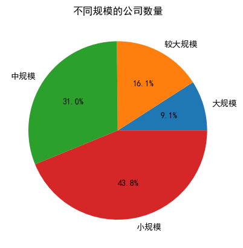

```python
plt.rcParams['font.sans-serif'] = 'SimHei' ## 设置中文显示
plt.rcParams['axes.unicode_minus'] = False ## 负的坐标 -10,
d1=data.drop_duplicates('公司名')
size1=d1.groupby(by='规模')['岗位'].count().sort_values()
print(size1)
plt.pie(size1, labels=size1.index, autopct='%.1f%%')
plt.title('不同规模的公司数量')
plt.show()
```

由上面的扇形图得知公司的规模构成,其中小规模和中规模占比之和为74.8%\ 规模越大公司的数量越少.

```
规模
较大规模    491
中规模     743
大规模     743
小规模     936
Name: 岗位, dtype: int64
```

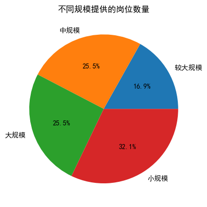

```python
size=data.groupby(by='规模')['岗位'].count().sort_values()
print(size)
plt.pie(size, labels=size.index, autopct='%.1f%%')
plt.title('不同规模提供的岗位数量')
plt.show()
```

由上面的扇形图得知,在不同规模公司提供的岗位数量上,小规模占比最多为32.1%,\ 其次是大规模、中规模公司占比均为25.5%，均提供了743个工作岗位，\ 较大规模公司工作岗位的占比最小,为16.9%

## 分组分析

### 根据公司规模分析

```python
d1=data.loc[data['规模']=='大规模','薪资']
d2=data.loc[data['规模']=='较大规模','薪资']
d3=data.loc[data['规模']=='中规模','薪资']
d4=data.loc[data['规模']=='小规模','薪资']
size={'大规模':d1.values,'较大规模':d2.values,'中规模':d3.values,'小规模':d4.values}
size_log={'大规模':np.log(d1.values),'较大规模':np.log(d2.values),'中规模':np.log(d3.values),'小规模':np.log(d4.values)}
```

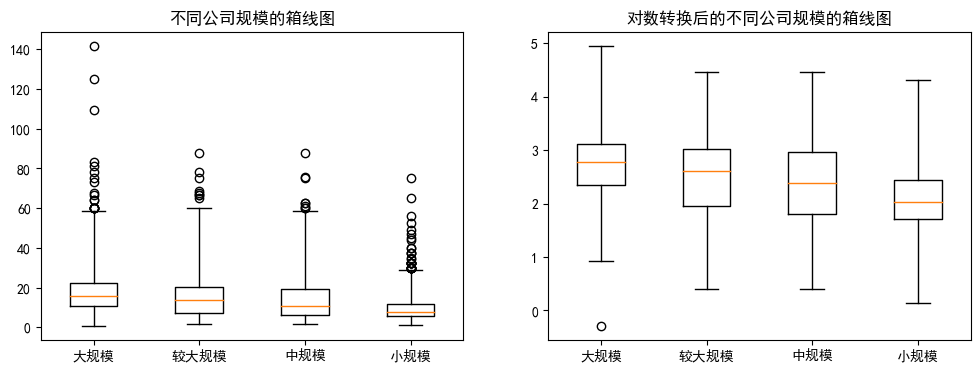

```python
plt.figure(figsize=(12,4))
plt.subplot(121)
plt.boxplot(x=size.values(),labels=size.keys(),whis=3)
plt.title('不同公司规模的箱线图')
plt.subplot(122)
plt.boxplot(x=size_log.values(),labels=size_log.keys(),whis=3)
plt.title('对数转换后的不同公司规模的箱线图')
plt.show()
```

因为原数据的箱线图较扁且异常值较多,所以对数据做对数转换\ 由对数转换后的箱线图可以看出,公司规模越大其工资水平越高\ 较大规模公司和中规模公司无明显差距

```python
size_salary=pd.DataFrame()
size_salary['总薪资']=data.groupby(by='规模')['薪资'].sum()
size_salary['岗位数量']=data.groupby(by='规模')['岗位'].count()
size_salary['最高工资']=data.groupby(by='规模')['薪资'].max()
size_salary['平均工资']=size_salary['总薪资']/size_salary['岗位数量']
size_salary['福利比例']=round(data[~data['福利'].isna()].groupby(by='规模')['规模'].count()/data.groupby(by='规模')['岗位'].count()*100,2)
size_salary=size_salary.sort_values('平均工资',ascending=False)
size_salary
```

| 规模 | 总薪资 | 岗位数量 | 最高工资 | 平均工资 | 福利比例 |
| --- | --- | --- | --- | --- | --- |
| 大规模 | 14476.26 | 743 | 141.67 | 19.483526 | 98.52 |
| 较大规模 | 8026.79 | 491 | 87.50 | 16.347841 | 96.95 |
| 中规模 | 10750.64 | 743 | 87.50 | 14.469233 | 90.58 |
| 小规模 | 9149.25 | 936 | 75.00 | 9.774840 | 69.44 |

### 根据地区分析

```python
area_salary=pd.DataFrame()
area_salary['总薪资']=data.groupby(by='地区')['薪资'].sum()
area_salary['岗位数量']=data.groupby(by='地区')['岗位'].count()
area_salary['平均工资']=area_salary['总薪资']/area_salary['岗位数量']
area_salary['大规模']=data[data['规模']=='大规模'].groupby(by=['地区'])['规模'].count()
area_salary['较大规模']=data[data['规模']=='较大规模'].groupby(by=['地区'])['规模'].count()
area_salary['中规模']=data[data['规模']=='中规模'].groupby(by=['地区'])['规模'].count()
area_salary['小规模']=data[data['规模']=='小规模'].groupby(by=['地区'])['规模'].count()
area_salary.fillna(0,inplace=True)
```

```python
area_salary_top=area_salary.sort_values('总薪资',ascending=False)[:10]
area_salary_top
```

| 地区 | 总薪资 | 岗位数量 | 平均工资 | 大规模 | 较大规模 | 中规模 | 小规模 |
| --- | --- | --- | --- | --- | --- | --- | --- |
| 北京 | 9478.83 | 445 | 21.300742 | 151.0 | 106.0 | 111.0 | 77.0 |
| 上海 | 5694.71 | 290 | 19.636931 | 92.0 | 59.0 | 77.0 | 62.0 |
| 深圳 | 4559.48 | 222 | 20.538198 | 86.0 | 32.0 | 53.0 | 51.0 |
| 杭州 | 3688.85 | 191 | 19.313351 | 53.0 | 36.0 | 57.0 | 45.0 |
| 南京 | 2481.22 | 145 | 17.111862 | 71.0 | 14.0 | 15.0 | 45.0 |
| 广州 | 2017.84 | 127 | 15.888504 | 24.0 | 35.0 | 39.0 | 29.0 |
| 成都 | 1325.11 | 102 | 12.991275 | 13.0 | 18.0 | 38.0 | 33.0 |
| 西安 | 1011.41 | 70 | 14.448714 | 30.0 | 9.0 | 18.0 | 13.0 |
| 武汉 | 820.73 | 60 | 13.678833 | 10.0 | 11.0 | 20.0 | 19.0 |
| 苏州 | 729.39 | 63 | 11.577619 | 9.0 | 13.0 | 18.0 | 23.0 |

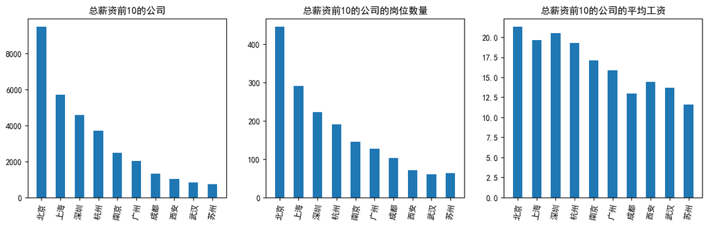

```python
plt.figure(figsize=(15,4))
plt.subplot(131)
plt.bar(x=area_salary_top.index, height=area_salary_top['总薪资'], width=0.5)
plt.xticks(rotation=80)
plt.title('总薪资前10的公司')
plt.subplot(132)
plt.bar(x=area_salary_top.index, height=area_salary_top['岗位数量'], width=0.5)
plt.xticks(rotation=80)
plt.title('总薪资前10的公司的岗位数量')
plt.subplot(133)
plt.bar(x=area_salary_top.index, height=area_salary_top['平均工资'], width=0.5)
plt.xticks(rotation=80)
plt.title('总薪资前10的公司的平均工资')
plt.show()
```

### 根据不同公司分析

```python
firm_salary=pd.DataFrame()
firm_salary['总薪资']=data.groupby(by='公司名')['薪资'].sum()
firm_salary['岗位数量']=data.groupby(by='公司名')['岗位'].count()
firm_salary['平均工资']=firm_salary['总薪资']/firm_salary['岗位数量']
firm_salary=firm_salary.sort_values('总薪资',ascending=False)
```

```python
firm_salary_top=firm_salary[:10]
firm_salary_top
```

| 公司名 | 总薪资 | 岗位数量 | 平均工资 |
| --- | --- | --- | --- |
| 中软国际 | 2649.90 | 151 | 17.549007 |
| 法本 | 842.25 | 67 | 12.570896 |
| 博彦科技 | 748.94 | 53 | 14.130943 |
| 软通动力信息技术集团 | 502.25 | 37 | 13.574324 |
| 华为 | 494.42 | 14 | 35.315714 |
| 腾讯 | 472.02 | 16 | 29.501250 |
| 华为技术有限公司 | 390.00 | 9 | 43.333333 |
| 京东集团 | 383.60 | 13 | 29.507692 |
| 中电金信 | 362.67 | 17 | 21.333529 |
| 百度 | 317.24 | 12 | 26.436667 |

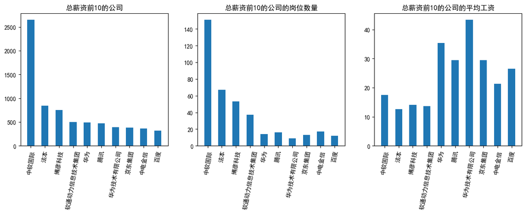

```python
plt.figure(figsize=(15,4))
plt.subplot(131)
plt.bar(x=firm_salary_top.index, height=firm_salary_top['总薪资'], width=0.5)
plt.xticks(rotation=80)
plt.title('总薪资前10的公司')
plt.subplot(132)
plt.bar(x=firm_salary_top.index, height=firm_salary_top['岗位数量'], width=0.5)
plt.xticks(rotation=80)
plt.title('总薪资前10的公司的岗位数量')
plt.subplot(133)
plt.bar(x=firm_salary_top.index, height=firm_salary_top['平均工资'], width=0.5)
plt.xticks(rotation=80)
plt.title('总薪资前10的公司的平均工资')
plt.show()
```

通过上面3个表得知,总薪资前10的公司的总薪资与岗位数量有较大关联。\ 总薪资和岗位数量前4的公司分别均为中软国际、法本、博彦科技、软通动力信息技术集团，\ 而平均工资前4的公司分别为华为技术有限公司、华为、京东集团、腾讯。\ 说明平均工资水平高的公司更需要的是高技术人员

```python
#这里认为岗位数量大于或等于5的公司是很注重数据分析的公司,并将其数据提取出来
work=firm_salary[firm_salary['岗位数量']>=5]
work
```

| 公司名 | 总薪资 | 岗位数量 | 平均工资 |
| --- | --- | --- | --- |
| 中软国际 | 2649.90 | 151 | 17.549007 |
| 法本 | 842.25 | 67 | 12.570896 |
| 博彦科技 | 748.94 | 53 | 14.130943 |
| 软通动力信息技术集团 | 502.25 | 37 | 13.574324 |
| 华为 | 494.42 | 14 | 35.315714 |
| 腾讯 | 472.02 | 16 | 29.501250 |
| 华为技术有限公司 | 390.00 | 9 | 43.333333 |
| 京东集团 | 383.60 | 13 | 29.507692 |
| 中电金信 | 362.67 | 17 | 21.333529 |
| 百度 | 317.24 | 12 | 26.436667 |
| 今日头条 | 309.75 | 14 | 22.125000 |
| 滴滴 | 283.77 | 10 | 28.377000 |
| 北京字节跳动 | 281.95 | 13 | 21.688462 |
| 阿里巴巴集团 | 272.75 | 9 | 30.305556 |
| 软通动力 | 239.38 | 15 | 15.958667 |
| 饿了么 | 234.75 | 6 | 39.125000 |
| 多益网络 | 231.74 | 13 | 17.826154 |
| 蚂蚁金服 | 228.66 | 6 | 38.110000 |
| 神州信息 | 228.46 | 18 | 12.692222 |
| BOSS直聘 | 227.99 | 8 | 28.498750 |
| 高德地图 | 218.50 | 5 | 43.700000 |
| 之江实验室 | 168.33 | 7 | 24.047143 |
| 阿里集团 | 165.41 | 5 | 33.082000 |
| 维智 | 151.58 | 5 | 30.316000 |
| 京东世纪贸易有限公司 | 147.40 | 7 | 21.057143 |
| 易观智库 | 113.76 | 6 | 18.960000 |
| 睿服科技 | 113.00 | 7 | 16.142857 |
| 中国移动研究院 | 106.68 | 5 | 21.336000 |
| 国双科技 | 104.40 | 7 | 14.914286 |
| 中科创达软件 | 102.00 | 6 | 17.000000 |
| 网易 | 101.78 | 7 | 14.540000 |
| 合合信息 | 82.58 | 7 | 11.797143 |
| 先进数通 | 79.50 | 5 | 15.900000 |
| 中电文思海辉 | 68.00 | 5 | 13.600000 |
| 朗新科技 | 64.88 | 5 | 12.976000 |
| 恒电科技 | 57.84 | 5 | 11.568000 |
| 滴滴出行 | 54.96 | 5 | 10.992000 |
| 中公教育 | 44.00 | 7 | 6.285714 |
| 51公积金管家 | 33.44 | 5 | 6.688000 |
| 浙江省北大信研院 | 24.67 | 6 | 4.111667 |
| 汇众天智 | 19.52 | 5 | 3.904000 |
| 傲创资产 | 10.50 | 5 | 2.100000 |

```python
#建立线性回归方程
from sklearn.linear_model import LinearRegression
X=work[['岗位数量']]
y=work[['总薪资']]
reg = LinearRegression().fit(X, y)
print('确定系数:',round(reg.score(X, y),2))
print('b 岗位对总薪资的影响系数:',reg.coef_[0].round(2))
print('a',reg.intercept_.round(2))
```

```
确定系数: 0.94
b 岗位对总薪资的影响系数: [16.28]
a [36.02]
```

确定系数为0.94，说明两者有较高的关联性\ 由上述结果可得出岗位数量与总薪资的线性回归方程:y=16.28*X+36.02 其中X为岗位数量,y为总薪资\ 即在很注重数据分析的公司中,预计每增加一个岗位则总薪资支出要多16.28k\ 我们可以根据方程用岗位数量来初步预测总薪资支出情况。

### 根据公司领域分析

```python
sector_salary=pd.DataFrame()
sector_salary['总薪资']=data.groupby(by='公司领域')['薪资'].sum()
sector_salary['岗位数量']=data.groupby(by='公司领域')['岗位'].count()
sector_salary['平均工资']=sector_salary['总薪资']/sector_salary['岗位数量']
sector_salary=sector_salary.sort_values('总薪资',ascending=False)
sector_salary_top=sector_salary[:10]
sector_salary_top
```

| 公司领域 | 总薪资 | 岗位数量 | 平均工资 |
| --- | --- | --- | --- |
| 计算机软件 | 12853.37 | 893 | 14.393471 |
| 互联网 | 8432.61 | 499 | 16.899018 |
| 移动互联网 | 3161.13 | 186 | 16.995323 |
| 电子商务 | 2037.75 | 120 | 16.981250 |
| 数据服务 | 1937.98 | 154 | 12.584286 |
| 智能硬件 | 1068.27 | 71 | 15.046056 |
| 通信/网络设备 | 973.14 | 58 | 16.778276 |
| 计算机服务 | 830.12 | 82 | 10.123415 |
| 企业服务 | 744.05 | 53 | 14.038679 |
| 培训机构 | 598.42 | 83 | 7.209880 |

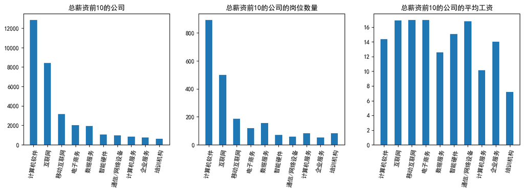

```python
plt.figure(figsize=(15,4))
plt.subplot(131)
plt.bar(x=sector_salary_top.index, height=sector_salary_top['总薪资'], width=0.5)
plt.xticks(rotation=80)
plt.title('总薪资前10的公司')
plt.subplot(132)
plt.bar(x=sector_salary_top.index, height=sector_salary_top['岗位数量'], width=0.5)
plt.xticks(rotation=80)
plt.title('总薪资前10的公司的岗位数量')
plt.subplot(133)
plt.bar(x=sector_salary_top.index, height=sector_salary_top['平均工资'], width=0.5)
plt.xticks(rotation=80)
plt.title('总薪资前10的公司的平均工资')
plt.show()
```

通过上面3个表得知,总薪资前10的公司领域的总薪资与岗位数量有较大关联。\ 总薪资和岗位数量前3的领域分别均为计算机软件、互联网、移动互联网，\ 平均工资前4的领域分别为互联网、移动互联网、电子商务、通讯\网络设备\ 说明互联网和移动互联网这两个领域的工作岗位多、平均工资高，是当前最受欢迎公司领域

### 根据公司福利分析

```python
welfare=pd.DataFrame()
welfare['总薪资']=data.groupby(by='是否有福利')['薪资'].sum()
welfare['岗位数量']=data.groupby(by='是否有福利')['岗位'].count()
welfare['平均工资']=welfare['总薪资']/welfare['岗位数量']
welfare=welfare.sort_values('总薪资',ascending=False)
welfare
```

| 是否有福利 | 总薪资 | 岗位数量 | 平均工资 |
| --- | --- | --- | --- |
| 有 | 38605.15 | 2531 | 15.252924 |
| 无 | 3797.79 | 382 | 9.941859 |

### 对学历分析

```python
data.groupby(by='学历要求')['薪资'].count()
```

```
学历要求
中专/中技      32
初中及以下       3
博士         29
大专       1205
学历不限      258
本科       1162
硕士        193
高中         31
Name: 薪资, dtype: int64
```

```python
education_salary=pd.DataFrame()
education_salary['总薪资']=data.groupby(by='学历要求')['薪资'].sum()
education_salary['岗位数量']=data.groupby(by='学历要求')['岗位'].count()
education_salary['平均工资']=education_salary['总薪资']/education_salary['岗位数量']
education_salary=education_salary.sort_values('平均工资',ascending=False)
education_salary
```

| 学历要求 | 总薪资 | 岗位数量 | 平均工资 |
| --- | --- | --- | --- |
| 博士 | 1316.46 | 29 | 45.395172 |
| 硕士 | 4164.96 | 193 | 21.580104 |
| 本科 | 20591.44 | 1162 | 17.720688 |
| 学历不限 | 3214.42 | 258 | 12.458992 |
| 大专 | 12732.55 | 1205 | 10.566432 |
| 初中及以下 | 31.50 | 3 | 10.500000 |
| 高中 | 191.50 | 31 | 6.177419 |
| 中专/中技 | 160.11 | 32 | 5.003438 |

```python
data['学历要求'].unique()
```

```
array(['本科', '硕士', '学历不限', '大专', '高中', '中专/中技', '博士', '初中及以下'],
      dtype=object)
```

```python
x1=data.loc[data['学历要求']=='博士','薪资']
x2=data.loc[data['学历要求']=='硕士','薪资']
x3=data.loc[data['学历要求']=='本科','薪资']
x4=data.loc[data['学历要求']=='大专','薪资']
x5=pd.concat([data.loc[data['学历要求']=='高中','薪资'],data.loc[data['学历要求']=='中专/中技','薪资']])
x6=data.loc[data['学历要求']=='学历不限','薪资']
study={'博士':x1.values,'硕士':x2.values,'本科':x3.values,'大专':x4.values,'高中及以下学历':x5.values,'学历不限':x6.values}
study_log={'博士':np.log(x1.values),'硕士':np.log(x2.values),'本科':np.log(x3.values),'大专':np.log(x4.values),'高中及以下学历':np.log(x5.values),'学历不限':np.log(x6.values)}
```

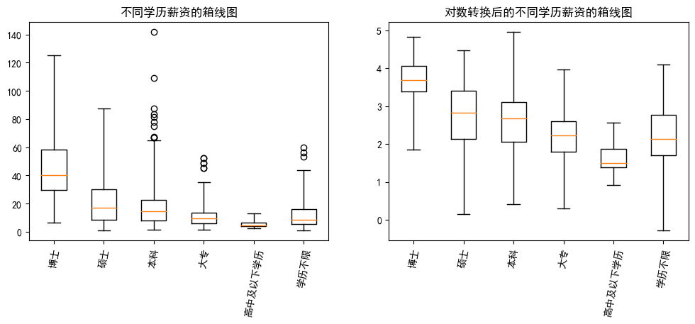

```python
plt.figure(figsize=(12,4))
plt.subplot(121)
plt.boxplot(x=study.values(),labels=study.keys(),whis=3)
plt.xticks(rotation=80)
plt.title('不同学历薪资的箱线图')
plt.subplot(122)
plt.boxplot(x=study_log.values(),labels=study_log.keys(),whis=3)
plt.xticks(rotation=80)
plt.title('对数转换后的不同学历薪资的箱线图')
plt.show()
```

从右上图我们可以知道,薪资越高所需要的工作要求越高\ 然后大专的薪资情况和学历不限的相差无几

### 对工作经验分析

```python
data.groupby(by='工作经验要求')['薪资'].count()
```

```
工作经验要求
在校/应届       197
工作经验要求低     257
工作经验要求正常    763
工作经验要求高     949
经验不限        747
Name: 薪资, dtype: int64
```

```python
w1=data.loc[data['工作经验要求']=='在校/应届','薪资']
w2=data.loc[data['工作经验要求']=='工作经验要求低','薪资']
w3=data.loc[data['工作经验要求']=='工作经验要求正常','薪资']
w4=data.loc[data['工作经验要求']=='工作经验要求高','薪资']
w5=data.loc[data['工作经验要求']=='经验不限','薪资']
work={'在校/应届':w1.values,'工作经验要求低':w2.values,'工作经验要求正常':w3.values,'工作经验要求高':w4.values,'经验不限':w5.values}
work_log={'在校/应届':np.log(w1.values),'工作经验要求低':np.log(w2.values),'工作经验要求正常':np.log(w3.values),'工作经验要求高':np.log(w4.values),'经验不限':np.log(w5.values)}
```

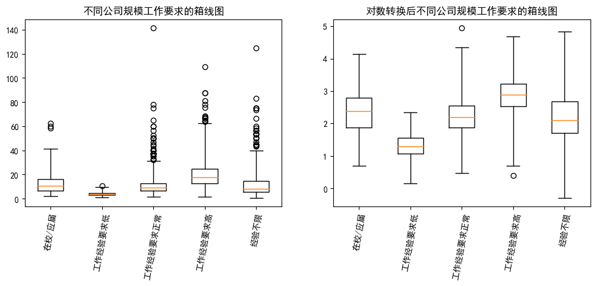

```python
plt.figure(figsize=(12,4))
plt.subplot(121)
plt.boxplot(x=work.values(),labels=work.keys(),whis=3)
plt.xticks(rotation=80)
plt.title('不同公司规模工作要求的箱线图')
plt.subplot(122)
plt.boxplot(x=work_log.values(),labels=work_log.keys(),whis=3)
plt.xticks(rotation=80)
plt.title('对数转换后不同公司规模工作要求的箱线图')
plt.show()
```

由右上的箱线图可知,薪资越高的岗位其工作经验要求越高\ 然后经验不限的工资情况与工作经验要求正常相差无几

### 对实习生数据分析

```python
p1=part_time.loc[part_time['规模']=='大规模','薪资']
p2=part_time.loc[part_time['规模']=='较大规模','薪资']
p3=part_time.loc[part_time['规模']=='中规模','薪资']
p4=part_time.loc[part_time['规模']=='小规模','薪资']
size_p={'大规模':p1.values,'较大规模':p2.values,'中规模':p3.values,'小规模':p4.values}
size_p_log={'大规模':np.log(p1.values),'较大规模':np.log(p2.values),'中规模':np.log(p3.values),'小规模':np.log(p4.values)}
```

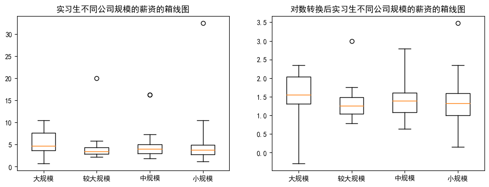

```python
plt.figure(figsize=(12,4))
plt.subplot(121)
plt.boxplot(x=size_p.values(),labels=size_p.keys(),whis=3)
plt.title('实习生不同公司规模的薪资的箱线图')
plt.subplot(122)
plt.boxplot(x=size_p_log.values(),labels=size_p_log.keys(),whis=3)
plt.title('对数转换后实习生不同公司规模的薪资的箱线图')
plt.show()
```

因为原数据的箱线图较扁且异常值较多,所以对数据做对数转换\ 由上图得知不同规模的实习生平均工资无太多差别。

### 地图词云图

```python
#词云图
import jieba
from PIL import Image
from wordcloud import WordCloud
import numpy as np
import matplotlib.pyplot as plt
```

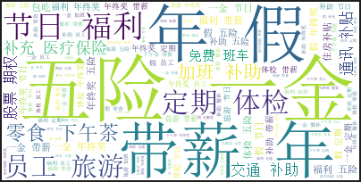

```python
text=data['福利'].replace('\n',"").str.split(',')
text=str(list(text))
text_cut = jieba.lcut(text)
# 将分好的词用某个符号分割开连成字符串
text_cut = ' '.join(text_cut)
# 结果当中或许存在着不少我们不需要看的、无关紧要的内容，这个时候就需要用到停用词
word_cloud = WordCloud(font_path="simsun.ttc",  # 设置词云字体
                       background_color="white") # 去掉的停词
word_cloud.generate(text_cut)
image = word_cloud.to_image()
image.show()
word_cloud.to_file("1.png")
plt.show()
```

由上面的词云图容易看出,在福利中五险一金出现次数最多,其次是年假.

```python
welfare1=data[data['是否有福利']=='有']
welfare2=welfare1[['五险一金' in i for i in welfare1['福利']]]
(welfare2.groupby(by='规模')['规模'].count()/data.groupby(by='规模')['规模'].count()).sort_values(ascending=False)*100
```

```
规模
大规模     97.308210
较大规模    94.093686
中规模     82.368775
小规模     59.188034
Name: 规模, dtype: float64
```

由上表易知公司规模越大五险一金的覆盖率越高